# Simulação de Monte Carlo e Cálculo do VPL

Author

Victor Schmidt Comitti

# Contexto

## Valor Presente Líquido (VPL)

O Valor Presente Líquido (VPL) é uma métrica financeira utilizada para avaliar a viabilidade de um projeto de investimento. Ele representa a soma dos fluxos de caixa futuros, descontados a uma taxa específica, menos o investimento inicial. O VPL é amplamente utilizado em finanças para determinar se um projeto gerará valor ao longo do tempo. Se o VPL for positivo, significa que o projeto é lucrativo.

A fórmula para o VPL é:

$$VPL = \sum_{t=1}^{n} \frac{FC_t}{(1+r)^t} - I_0$$

Onde: - ( FC_t ) é o fluxo de caixa no período ( t ) - ( r ) é a taxa de desconto - ( I_0 ) é o investimento inicial

## Simulação de Monte Carlo

A Simulação de Monte Carlo é uma técnica estatística usada para modelar a incerteza em processos de decisão. Ela envolve a realização de experimentos aleatórios repetidos para simular a variabilidade dos possíveis resultados de um evento ou processo. No contexto do cálculo de VPL, podemos usar a Simulação de Monte Carlo para modelar a incerteza nos fluxos de caixa futuros, assumindo que seguem uma distribuição de probabilidade específica (por exemplo, Normal).

# Tarefa

### Objetivo

Você deve calcular a probabilidade de um projeto de investimento gerar um VPL positivo usando a técnica de Simulação de Monte Carlo.

### Descrição

Considere um projeto de investimento onde os fluxos de caixa anuais seguem uma distribuição Normal, conforme os parâmetros indicados na tabela abaixo. O investimento inicial é de 500 unidades monetárias e a taxa de desconto é de 10%. Utilize Simulação de Monte Carlo para estimar a probabilidade de o VPL ser positivo.

| Ano | Média do Fluxo de Caixa | Desvio Padrão |
| --- | --- | --- |
| 1 | 100 | 20 |
| 2 | 150 | 30 |
| 3 | 120 | 25 |
| 4 | 200 | 40 |
| 5 | 180 | 35 |

### Instruções

1. **Monte Carlo**: Simule 10.000 cenários para os fluxos de caixa de cada ano, considerando que eles seguem distribuições Normais com as médias e desvios padrão fornecidos.
2. **Cálculo do VPL**: Para cada cenário simulado, calcule o VPL do projeto.
3. **Probabilidade**: Calcule a proporção de cenários onde o VPL é positivo. Esta proporção representa a probabilidade de o projeto ser lucrativo.
4. **Visualização**: Plote o histograma dos VPLs simulados e destaque a região onde o VPL é maior que zero.

### Exemplo em R considerando apenas tres fluxos de caixa

```r
# Parâmetros
n_simulacoes <- 10000
taxa_desconto <- 0.10
investimento_inicial <- 500

# Definir as distribuições dos fluxos de caixa
fluxo_ano1 <- rnorm(n_simulacoes, mean = 100, sd = 20)
fluxo_ano2 <- rnorm(n_simulacoes, mean = 150, sd = 30)
fluxo_ano3 <- rnorm(n_simulacoes, mean = 200, sd = 40)

# Calcular o VPL para cada simulação
VPL <- (fluxo_ano1 / (1 + taxa_desconto)^1) +
       (fluxo_ano2 / (1 + taxa_desconto)^2) +
       (fluxo_ano3 / (1 + taxa_desconto)^3) -
       investimento_inicial

# Calcular a probabilidade de o VPL ser positivo
prob_vpl_positivo <- mean(VPL > 0)
cat('Probabilidade de VPL positivo:', prob_vpl_positivo, '\n')
```

```
Probabilidade de VPL positivo: 9e-04
```

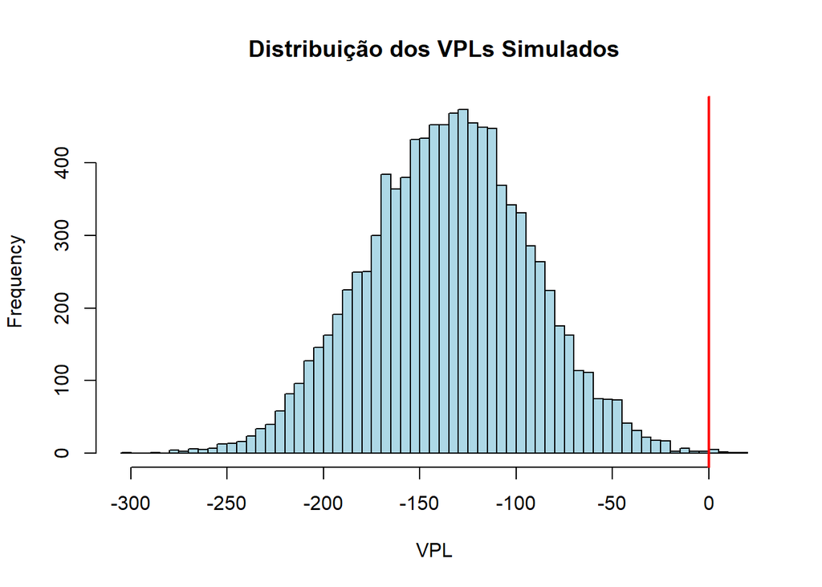

```r
# Visualizar o histograma dos VPLs
hist(VPL, breaks = 50, main = "Distribuição dos VPLs Simulados",
     xlab = "VPL", col = "lightblue", border = "black")
abline(v = 0, col = "red", lwd = 2)
```